# Notebook

### 파이썬 시각화 기초 - 구글 트렌드로 알아보는 데이터속의 신호

### Data

#### 구글 트렌드 데이터

[housing bubble](https://trends.google.co.kr/trends/explore?date=all&geo=US&q=housing%20bubble) housing_bubble.csv  
[18대 대선](https://trends.google.co.kr/trends/explore?date=2012-11-01%202012-12-18&geo=KR&q=%EB%B0%95%EA%B7%BC%ED%98%9C,%EB%AC%B8%EC%9E%AC%EC%9D%B8) dae18.csv  
[19대 대선](https://trends.google.co.kr/trends/explore?date=2017-04-01%202017-05-08&geo=KR&q=%EB%AC%B8%EC%9E%AC%EC%9D%B8,%ED%99%8D%EC%A4%80%ED%91%9C,%EC%95%88%EC%B2%A0%EC%88%98) dae19.csv  
[인버스](https://trends.google.co.kr/trends/explore?date=today%205-y&geo=KR&q=%EC%9D%B8%EB%B2%84%EC%8A%A4) inverse.csv

#### 미국 집값 데이터

[미국 집값 데이터](https://www.fhfa.gov/DataTools/Downloads/Documents/HPI/HPI_PO_monthly_hist.xls)

### 미국 집값 VS 검색어 'housing bubble'

|  | Month | value |
| --- | --- | --- |
| 0 | 2004-01-01 | 181.89 |
| 1 | 2004-02-01 | 183.26 |
| 2 | 2004-03-01 | 184.55 |
| 3 | 2004-04-01 | 186.09 |
| 4 | 2004-05-01 | 187.88 |

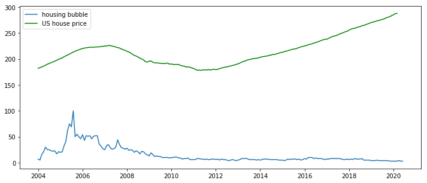

미국 집값 그래프를 보면 서브프라임 모기지 사태(2007년 중후반)이후로 집값이 급격하게 떨어짐을 알 수 있다.  
'housing bubble(집값 거품)'이라는 단어는 2005년 후반부에 구글 검색량이 비약적으로 증가했다.  
이 housing bubble이라는 검색량 증가가 서브프라임 사태를 예측할 수 있는 신호로 볼 수 있었을까?

### 18,19대 대선 결과와 구글 트렌드 대통령 이름 검색 비교

대선 시기 약 40일 전부터 대선 전날까지의 검색어 트렌드

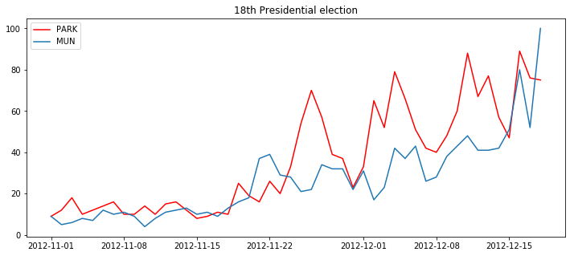

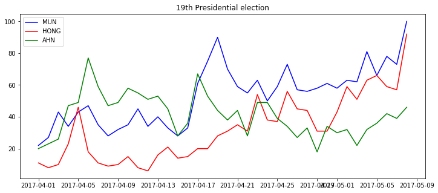

18대 대선에서는 박근혜 전대통령이 당선되었고, 19대 대선에서는 문재인 대통령이 당선되었다. 그리고 각 후보의 검색량을 보면 검색량이 제일 많은 후보가 실제로 당선되었음을 알 수 있다.  
대선 후보의 검색량도 대선 결과를 맞추는데 이용할 수 있는 신호라고 할 수 있을까?

### 코스피 지수 VS 검색어 '인버스'

검색어 인버스의 단위는 1주일이다.

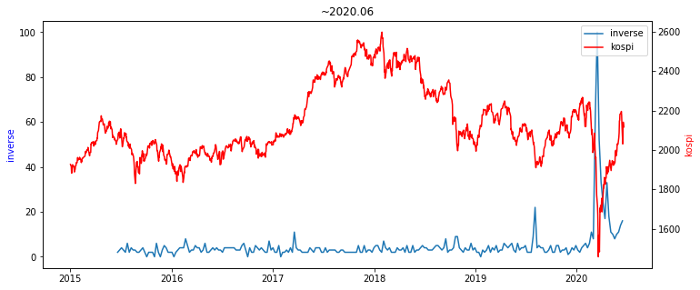

2019년 중반부와 2020년 3월경을 보면 inverse라는 검색어가 급격히 많이 올라갔음을 알 수 있다. 그리고 이때 코스피 지수는 다른 날들에 비해 낮은 값을 가지고 있다. 그렇다면 이러한 것을 코스피 지수와 관련된 신호로 볼 수 있을까?

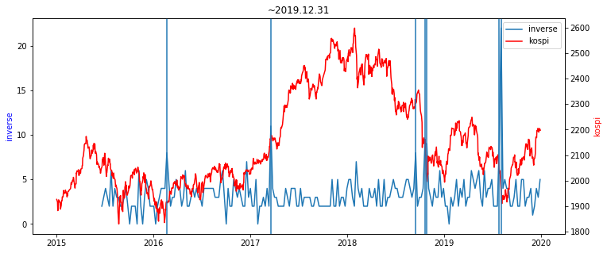

코로나로 인해 인버스 검색량은 2020년 초반에 압도적으로 많았고, 상대적으로 다른 기간의 분포는 보기가 힘들었다. 그래서 기간을 2019년 12월 31일까지로 설정한 후 두 값들의 관계를 살펴봤다.  
인버스 검색량이 상승한 주(값이 8 이상인 주)를 수직선으로 표시했다. 위의 결과와는 다르게 이 기간들에서 코스피지수는 다른 구간에 비해 높은 값을 가지는 구간도 존재했다(2018년 후반부). 만약 이 시점에 인버스 검색어를 신호로보고 주식을 매수했다면 2~3달 후 손해를 볼 확률이 높았을 것이다.  
어떤 신호를 보고 판단을 할 때는 몇가지의 예시로 일반화 하는것이 아니라 끊임없이 의심하고 유효한지 여부를 검증해 좋은 신호를 골라내야할 것이다.